# Mieten in Deutschland

Worin liegen Probleme und Schwierigkeiten im deutschen Mietmarkt

# Motivation

Die Mietpreise in Deutschland spielen eine wichtige Rolle für eine Vielzahl der deutschen Bevölkerung, doch nicht alle Gemeinden sind gleichermaßen von hohen Mieten betroffen. Faktoren wie die Lage einer Stadt, das Angebot an Wohnraum, das Alter der Gebäude oder der Familienstand der Bewohner beeinflussen die Höhe der Mieten. Dies werden Sie in diesem Projekt anhand von Zensus-Daten auf Gemeindeebene für das Jahr 2022 genau untersuchen. Besonders interessant ist dabei, wie sich Mietpreise nicht nur zwischen verschiedenen Städten, sondern auch innerhalb einer Stadt unterscheiden. Sie werden feststellen, dass die Ursachen für diese Mietunterschiede komplex und vielschichtig sind. Ihre Aufgabe ist es, durch fundierte Analysen herauszuarbeiten, welche Faktoren den größten Einfluss auf die Mietentwicklung haben. Auf Basis dieser Erkenntnisse könnten Sie Handlungsempfehlungen geben, die Politik und Stadtplaner nutzen können, um die Mietpreisentwicklung besser zu steuern und Wohnraum gerechter zu gestalten.

# Datengrundlage

In diesem Projekt werden Sie mit mehreren unterschiedlichen Datensätzen arbeiten. Zum Einen werden Sie Zensusdaten aus dem Jahr 2022 zur Demografie genauer betrachten. Zum Anderen werden Sie Daten zur Wohnungszählung in deutschen Gemeinden und Städten untersuchen. Schließlich benötigen Sie die dazugehörigen Kartendaten, um die Informationen später anschaulich visualisieren zu können. Dort werden Sie die Details der Karten einlesen und darüber hinaus Zahlen zu Mieten selbstständig herunterladen und importieren.

## Einlesen

Mittlerweile wohnen knapp 54% der Menschen in Deutschland zur Miete (Stand 2022). Somit ist Deutschland das Mieterland Nummer 1 in Europa. Im Vergleich dazu haben Länder wie Frankreich (36,6%), Italien (25,7%) oder Spanien (24%) einen deutlich geringeren Anteil an Mietern. Für die Politik ist es besonders interessant zu erfahren, wie sich nun die Mieten in den unterschiedlichen Gemeinden in Deutschland verteilen und ob es Regionen gibt, wo es besonders schwer wird eine neue Wohnung zu finden. Um dies zu beleuchten, sollen Sie nun die nachfolgenden Datensätze genauer analysieren.

1. Lesen Sie den Datensatz `Demografie_Zensus.csv` ein und speichern diesen als `demografie`. Der Datensatz `demografie` enthält für jede Gemeinde mehrere Beobachtungen. Dies liegt daran, dass für jede Altersgruppe der Personen eine eigene Beobachtung vorliegt. Allerdings ist der Datensatz im long-Format, d.h. nicht tidy und damit nicht so, wie Sie ihn für die weitere Datenanalyse benötigen. Nun soll der Datensatz so abgeändert werden, dass jede Gemeinde nur noch eine Beobachtung darstellt. Passen Sie den Datensatz so an, dass Sie für jede `Altersgruppe` eine eigene Spalte erstellen und dort jeweils die Anzahl der Menschen, die Sie der Spalte `Anzahl pro Altersgruppe` entnehmen können, eingetragen wird.

Darüberhinaus sollen Sie nun einen weiteren Datensatz `Wohnungen_Zensus.csv` einlesen, welcher Informationen zu den einzelnen Wohnungen in den Gemeinden enthält. Speichern Sie den Datensatz in der Variable `wohnungen` ab. Vereinen Sie ihren Datensatz `demografie` mit dem Datensatz `wohnungen` und speichern Sie diesen als `zensus_daten` ab. Verwenden Sie für ihren “Join” die Variable `Regionalschlüssel`.

Beantworten Sie anschließend die Frage, welche Art von “Join” sich in diesem Fall anbietet und warum?

An dieser Stelle bietet es sich der sogenannte `left_join`an, da  
die Daten bezüglich der Demografie in den darrauffolgenden Aufgaben noch als Hauptgrundlage für weitere analysen verwendet werden.

2. Schränken Sie nun Ihren erstellten Datensatz auf folgende Variablen ein:
- `Name_Gemeinde`
- `Landkreis`
- `0_Insgesamt_`
- `Regionalschlüssel`
- `Alter_infr__` (01 bis 11)
- `FAMSTND_KURZ__` (1 bis 5)
- `Einwanderungserf_ausf__1`
- `Einwanderungserf_ausf__21`
- `Einwanderungserf_ausf__22`
- `Einwanderungserf_ausf__3`
- `Staatsange_kurz__1`
- `Staatsange_kurz__2`
- `BAUJAHR_10JA__` (01 bis 10)
- `WOHNFLAECHE_20S__` (01 bis 10)
- `QMMIETE`
- `LEQ`
- `ETQ`
- `FLAECHE`
- `Wohnungen_gesamt`

Beschreiben Sie weiterhin den Datensatz. Orientieren Sie sich hierbei an folgenden Fragen und nutzen Sie das bereitgestellte README zum Datensatz:

- Was ist eine Beobachtung?
- Wie viele Variablen hat der Datensatz?
- Welche Variablen enthält der Datensatz? Bitte beschreiben Sie diese Variablen kurz!
- Welche Städte mit mehr als 500.000 Einwohnern sind im Datensatz?
- In wie viel Prozent der Fälle haben Sie Informationen zu allen Variablen einer Beobachtung?

| Stadt | Einwohnerzahl |
| --- | --- |
| Berlin, Stadt | 3596999 |
| Bremen, Stadt | 575071 |
| Dortmund, Stadt | 598246 |
| Dresden, Stadt | 557782 |
| Duisburg, Stadt | 501415 |
| Düsseldorf, Stadt | 611258 |
| Essen, Stadt | 571039 |
| Frankfurt am Main, Stadt | 743268 |
| Hamburg, Freie und Hansestadt | 1808846 |
| Hannover, Landeshauptstadt | 513291 |
| Köln, Stadt | 1017355 |
| Leipzig, Stadt | 598899 |
| München, Landeshauptstadt | 1478638 |
| Nürnberg | 522554 |
| Stuttgart, Landeshauptstadt | 610458 |

3. Erstellen Sie in einem nächsten Schritt weitere Variablen, die Sie in ihrer Analyse benötigen. Diese Variablen sollen folgende Eigenschaften umfassen:
- Je eine Variable für den Anteil kleiner, mittlerer und großer Wohnungen, wobei kleine Wohnungen (<= 59 m²), mittlere Wohnungen (60 - 159 m²) und große Wohnungen (>= 160 m²) als Anteil an den `Wohnungen_gesamt` abgebildet werden sollen.
- Je eine Variable für den Anteil neuer und alter Wohnungen. Neue Wohnungen umfassen alle Wohnungen, die ab 2010 gebaut wurden und alte Wohnungen sind alle Wohnungen vor 1950. Auch hier soll wieder der Anteil an allen Wohnungen (`Wohnungen_gesamt`) berechnet werden.
- Das Verhältnis von Personen mit deutscher Staatsangehörigkeit zu allen Bürgern der Gemeinde einschliesslich Personen mit ausländischer Staatsangehörigkeit und Personen mit dem Status “staatenlos”, “ungeklärt” und “ohne Angabe” über `Staatsange_kurz__1` und `Staatsange_kurz__2`. Hier soll der Anteil deutscher Bürger im Verhältnis zu allen Bürgern der Gemeinde bestimmt werden.

*Hinweis:* Runden Sie die Werte für die neu erstellte Variable sinnvoll!

4. Um Karten wie bspw. in der Case Study zu erstellen, benötigen Sie Kartendaten in Form von Shapefiles (Endung .shp). In einer späteren Analyse sollen Sie die einzelnen Städte, bzw. deren Bezirke visualisieren. Hierzu müssen Sie zuerst die nötigen Shape-Files einlesen und Details zu den einzelnen Bezirken herunterladen. Sie sollen Analysen auf Basis von 1km Gitterdaten durchführen. Deshalb sollten Sie sich [diese Geogitter-Daten für die Nettokaltmieten vom statistischen Bundesamt herunterladen](https://www.zensus2022.de/static/Zensus_Veroeffentlichung/Zensus2022_Durchschn_Nettokaltmiete.zip). Speichern Sie die zip-Datei im Ordner `Daten` ab. Weiterhin sollen Sie [die Geogitter-Daten für die Leerstandsquoten herunterladen](https://www.zensus2022.de/static/Zensus_Veroeffentlichung/Marktaktive_Leerstandsquote_in_Gitterzellen.zip). Speichern Sie auch diese im Ordner `Daten` ab und lesen Sie anschließend die .csv-Dateien für Nettokaltmiete und Leerstandsquote (für das 1km-Gitter) ein. Weiterhin benötigen Sie die Karteninformationen für die Visualisierung der Daten. Diese befinden sich in der Datei `Shapefile_Zensus.shp`. Lesen Sie diese mit Hilfe von `st_read()` ein und speichern Sie als `shape_file` ab. Benennen Sie die Variablen in `shape_file` folgendermaßen um:
- gemndnm = Name_Gemeinde
- x_mp_1k = x_mp_1km
- y_mp_1k = y_mp_1km
- gttr1km = gitter1km

Joinen Sie nun noch die beiden Dataframes zu Miete und Leerstandsquote zu `shape_file` hinzu. Verwenden Sie `y_mp_1km` und `x_mp_1km` als Joinvariable.

*Hinweis:* Im ersten Teil der Case-Study wird eine ZIP-Datei in R entpackt. Gehen Sie hier gleich vor!

# Konsistenzcheck

Nun haben Sie alle Daten zusammen, die Sie für die Analyse der Mieten in Deutschland für das Jahr 2022 benötigen. Somit können Sie nun beginnen, die ersten Analysen zu tätigen!

5. Im Datensatz `zensus_daten`, welchen Sie zuvor eingelesen, aufgearbeitet und zusammengefügt haben, befinden sich einige große deutsche Städte. Sie möchten nun gerne die Daten, welche Sie dort aufbereitet haben, verifizieren. Dafür sollten Sie sich eine externe Quelle suchen, auf deren Basis Sie die Gesamtbevölkerung der unten aufgeführten großen Städte in Deutschland mit denen aus dem Datensatz vergleichen. Die Bevölkerungszahlen in ihrem Datensatz stammen aus dem Jahr 2022.

Erstellen Sie eine Tabelle mit allen nachfolgenden Städten aus dem Datensatz und deren Einwohnern. Achten Sie auf eine schöne Darstellung ihrer Tabelle mittels der Pakete `kableExtra` oder `gt`.

Im Detail sollen folgende Städte in der Tabelle genauer betrachtet werden:

- “Berlin, Stadt”, “Hamburg, Freie und Hansestadt”, “München, Landeshauptstadt”, “Köln, Stadt”, “Frankfurt am Main, Stadt”, “Stuttgart, Landeshauptstadt”, “Düsseldorf, Stadt”, “Leipzig, Stadt”, “Augsburg”, “Ingolstadt”, “Ulm, Universitätsstadt”, “Reutlingen, Stadt”

Sind die Anzahl der Einwohner in ihren Daten korrekt? Nutzen Sie eine externe Datenquelle (bitte benennen und in ihrer Antwort verlinken) und führen Sie einen kurzen Konsistenzcheck durch.

Einwohnerzahlen ausgewählter Städte

| Stadt | Einwohneranzahl(Zensus 2022) | Einwohner (gemäß externer Quellen) | Differenz |
| --- | --- | --- | --- |
| Reutlingen, Stadt | 116925 | 116476 | 449 |
| Ulm, Universitätsstadt | 127116 | 129158 | -2042 |
| Ingolstadt | 136468 | 138263 | -1795 |
| Augsburg | 294647 | 304105 | -9458 |
| Leipzig, Stadt | 598899 | 597493 | 1406 |
| Stuttgart, Landeshauptstadt | 610458 | 630305 | -19847 |
| Düsseldorf, Stadt | 611258 | 620523 | -9265 |
| Frankfurt am Main, Stadt | 743268 | 770166 | -26898 |
| Köln, Stadt | 1017355 | 1092118 | -74763 |
| München, Landeshauptstadt | 1478638 | 1588330 | -109692 |
| Hamburg, Freie und Hansestadt | 1808846 | 1889000 | -80154 |
| Berlin, Stadt | 3596999 | 3850809 | -253810 |

Bei den Externen Quellen umfassen teiweise Daten, welche die Gemeinden selbst veröffentlichen sowie Informationen welche das Magazin Handelsblatt, basierend auf Informationen von Statista herausgibt. Gemäß der obigen Tabelle können wir sehen, dass zwischen beiden Quellen durchaus Diskrepanzen bestehen. Dies lässt sich unteranderem darauf zurückführen, dass der Zeitpunkt der Erhebung unterschiedlich ist.

Desweiteren könnten die Daten die Anzahl an Personen berücksichtigen, welche nicht mehr tatsächlich in der Stadt wohnen, so wie es bei den Daten der Stadt Köln der Fall ist.

Es könnten auch Unterschiede in der Mehtodik zwischen beiden Datensätzen vorliegen.

Externe Quellen:

https://www.reutlingen.de/ceasy/resource/?id=55634&download=1 https://www.statistik-nord.de/fileadmin/Dokumente/Statistische_Berichte/bevoelkerung/A_I_8_j_HH/A_I_8_j19_HH.pdf https://www.statistik-berlin-brandenburg.de/kommunalstatistik/einwohnerbestand-berlin https://stadt.muenchen.de/dam/jcr:c45700b2-e2c3-4d66-99fa-55e4c77ab3ee/jt240101.pdf https://www.stadt-koeln.de/mediaasset/content/pdf15/statistik-einwohner-und-haushalte/ksn_8_2023_bev%C3%B6lkerungsentwicklung_2022.pdf https://frankfurt.de/-/media/frankfurtde/service-und-rathaus/daten-informationen-wissen/pdf/pdf-fsa/2024/fsa_2024_04_bevoelkerung_ende2023.pdf https://statistikinteraktiv.augsburg.de/Interaktiv/JSP/main.jsp?mode=Detailansicht&area=Stadt&id=A&detailView=true https://www.ingolstadt.de/Rathaus/Aktuelles/Zahlen-Daten/Aktuelle-Statistiken/ https://www.handelsblatt.com/politik/deutschland/ranking-2022-das-sind-die-zehn-groessten-staedte-deutschlands/24407466 html

# Deskriptive Analysen

6. Schauen Sie sich in einem nächsten Schritt an, wie die Variablen im Datensatz `zensus_daten` über alle Gemeinden und Städte hinweg verteilt sind. Konkret sollten Sie eine Tabelle erstellen, welche Informationen zu folgenden Variablen enthält:
- verschiedene Baujahre der Wohnungen
- durchschnittlicher Quadratmeterpreis
- Leerstandsquote
- Eigentümerquote
- durchschnittliche Wohnfläche
- Anteil kleiner, mittlerer und großer Wohnungen
- Einwohner

Berechnen Sie zu jeder Variablen den Mittelwert, den Median, das Minimum, das Maximum, die Standardabweichung, sowie das 25%- und das 75%- Quantil bezogen auf alle Gemeinden. Bei den Variablen Leerstandsquote, Eigentümerquote, durchschnittliche Wohnfläche, durchschnittlicher Quadratmeterpreis und Anteil kleiner, mittlerer und großer Wohnungen soll der Mittelwert als gewichteter Mittelwert nach der absoluten Anzahl an Wohnungen berechnet werden. Heben Sie die Variablen in ihrer Tabelle entsprechend hervor, bei denen sie den gewichteten Mittelwert bestimmt haben.

Beschreiben und interpretieren Sie Ihre Tabelle. Begründen Sie auch, warum es bei den genannten Variablen sinnvoll ist, den nach Anzahl der Wohnungen gewichteten Mittelwert zu verwenden. Würde es ihrer Ansicht nach Sinn machen, statt nach Wohnungen nach Einwohnern zu gewichten? Begründen Sie auch, bei welchen Variablen eine Betrachtung der Mittelwerte, Standardabweichungen und Quantile ihrer Ansicht nach als sinnvoll erscheint. Wo ist dies weniger gut geeignet? Bei welchen Variablen gibt es Auffälligkeiten? Gibt es Ausreißer nach oben oder unten?

Achten Sie auf eine schöne Darstellung ihrer Tabelle mittels der Pakete `kableExtra` oder `gt`!

*Hinweis 1:* Wenn bei den Variablen Wohnungen_klein, Wohnungen_mittel und Wohnungen_groß Werte mit `NaN` oder `Inf` auftauchen, so ersetzen Sie diese durch `NAs`.

*Hinweis 2:* Die Anzahl der Wohnungen nach Alters- bzw. Baujahrsgruppen können den Variablen entnommen werden, welche mit `BAUJAHR_10JA__` beginnen.

| Variable | Mittelwert | Standardabweichung | Minimum | 25%-Quartil | 50%-Quartil | 75%-Quartil | Maximum |
| --- | --- | --- | --- | --- | --- | --- | --- |
| Wohnungen vor 1919 | 527.590188 | 5692.466478 | 0.00 | 50.00 | 111.00 | 316.00 | 520700.00 |
| Wohnungen 1919-1949 | 410.884355 | 3526.982774 | 0.00 | 28.00 | 69.00 | 221.00 | 281150.00 |
| Wohnungen 1950-1959 | 458.390058 | 3943.251712 | 0.00 | 20.00 | 60.00 | 198.00 | 193475.00 |
| Wohnungen 1960-1969 | 608.002040 | 4351.183173 | 0.00 | 30.00 | 94.00 | 337.50 | 261728.00 |
| Wohnungen 1970-1979 | 579.822220 | 3426.958322 | 0.00 | 33.00 | 113.00 | 388.50 | 239857.00 |
| Wohnungen 1980-1989 | 395.808959 | 2676.069007 | 0.00 | 29.00 | 91.00 | 295.00 | 223683.00 |
| Wohnungen 1990-1999 | 479.417231 | 2131.734183 | 0.00 | 39.00 | 124.00 | 407.00 | 141456.00 |
| Wohnungen 2000-2009 | 251.930539 | 1114.234416 | 0.00 | 23.00 | 69.00 | 204.00 | 57008.00 |
| Wohnungen 2010-2015 | 129.777706 | 828.185270 | 0.00 | 8.00 | 26.00 | 88.00 | 45389.00 |
| Wohnungen ab 2016 | 155.932579 | 1101.492964 | 0.00 | 9.00 | 33.00 | 115.00 | 80878.00 |
| Anteil kleiner Wohnungen | 5.680000 | 2.410000 | 0.00 | 0.79 | 1.60 | 2.85 | 29.85 |
| Anteil mittlere Wohnungen | 88.580000 | 5.240000 | 0.00 | 84.34 | 87.65 | 90.49 | 100.00 |
| Anteil große Wohnungen | 5.740000 | 5.600000 | 0.00 | 6.75 | 10.35 | 14.02 | 100.00 |
| Durchschnittlicher Quadratmeterpreis | 7.000000 | 1.380000 | 0.00 | 4.82 | 5.53 | 6.46 | 13.84 |
| Leerstandsquote | 4.337385 | 3.113072 | 0.00 | 3.45 | 4.74 | 6.58 | 50.00 |
| Eigentümerquote | 44.364371 | 12.721525 | 13.49 | 60.22 | 68.77 | 76.11 | 100.00 |
| Einwohnerzahl | 7668.392546 | 49517.097822 | 9.00 | 655.00 | 1797.00 | 5506.00 | 3596999.00 |
| durchschnittliche Wohnfläche | 94.315866 | 15.413396 | 64.92 | 104.98 | 116.20 | 125.11 | 239.54 |

Die Tabelle listet die statistischen Kennzahlen (Mittelwert, Standardabweichung etc.) zu den Variablen aus der Aufgabenstellung auf. Würde man die genannten Variablen nicht nach der Anzahl der Wohnungen gewichten, könnten die Ergebnisse durch kleinere Gemeinden mit weniger Wohnungen unverhältnismäßig stark beeinflusst werden.

Man erkennt, dass der durchschnittliche Quadratmeterpreis bei 7,00 Euro liegt. Die große Spannweite zwischen dem 25%-Quartil und dem Maximum deutet jedoch auf erhebliche regionale Unterschiede hin.

Die durchschnittliche Eigentümerquote liegt bei 44,3 % und damit deutlich unter dem europäischen Durchschnitt von 69 % (Quelle: https://bankenverband.de/finanzbildung/miete-populaerer-als-eigentum-deutschland/ ). Es gibt jedoch auch Regionen mit einer Eigentümerquote von bis zu 100 %.

Die durchschnittliche deutsche Gemeinde hat 7.668 Einwohner. Das Maximum zeigt jedoch, dass die Statistik durch große Städte wie Berlin stark beeinflusst wird.

Die durchschnittliche Wohnfläche beträgt 94,32 m². Es gibt jedoch Regionen, in denen die Wohnungen durchschnittlich deutlich größer sind.

7. Die Verteilung des Alters der Wohnungen scheint bereits ein Faktor zu sein, der sich auf den Mietpreis auswirken kann, da doch deutlich weniger Wohnungen ab den 2000er Jahren gebaut wurden. Nun sollen Sie etwas tiefer in ihren Datensatz eintauchen und weitere Faktoren analysieren, die sich zum einen zwischen Städten und Gemeinden unterscheiden und darüberhinaus herausfinden, ob diese Faktoren einen Einfluss auf den Mietpreis haben:

Erstellen Sie 4 Punktdiagramme in denen Sie

- die durchschnittliche Fläche je Wohnung,
- die Leerstandsquote je Gemeinde,
- Anteil alter Wohnungen je Gemeinde,
- Anteil neuer Wohnungen je Gemeinde,

auf der x-Achse abtragen und auf der y-Achse jeweils die durchschnittliche Nettokaltmiete pro Quadratmeter. Verwenden Sie hier nun alle Gemeinden im Datensatz, um ein Gesamtbild zu erhalten und ordnen Sie die 4 Diagramme so an, dass ein Vergleich zwischen den Schaubildern schnell und einfach möglich ist. Beschreiben und interpretieren Sie die Diagramme. Gehen Sie hierbei insbesondere auf folgende Fragen ein:

- Welche Variablen scheinen besonders stark mit dem Mietpreis korreliert zu sein?
- Was könnte die Zusammenhänge erklären?

*Hinweis:* Achten Sie darauf das bei nebeneinander angeordneten Grafiken die y-Achse gleich sein sollte.

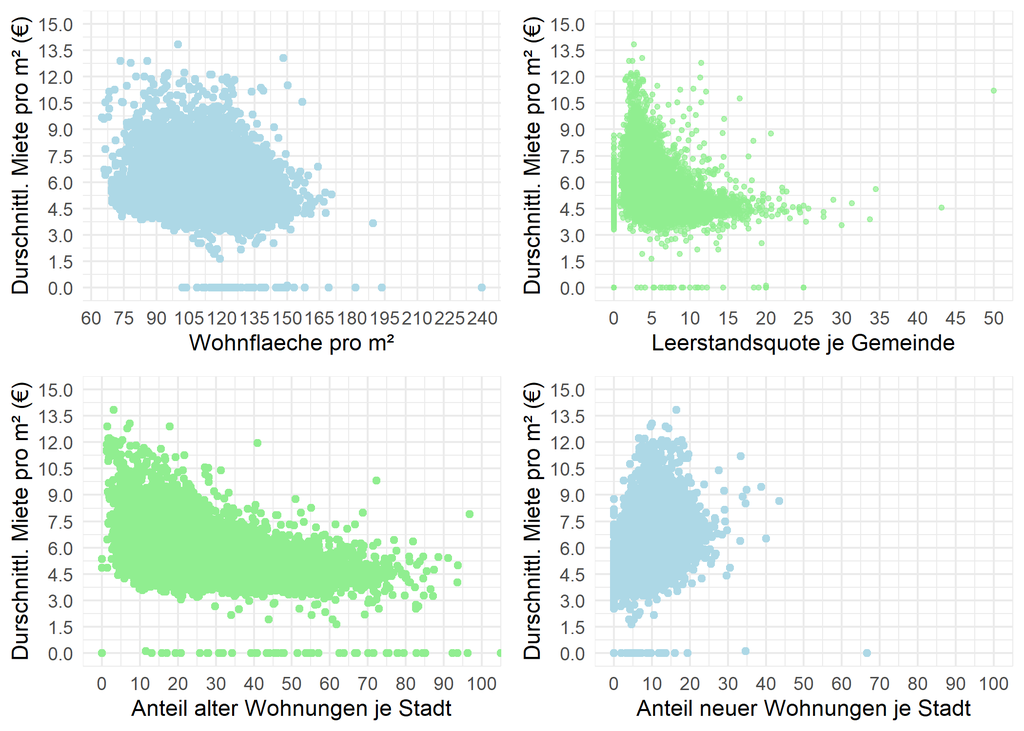

Wie aus den Abbildungen hervorgeht, korrelieren die Leerstandsquote und der Anteil alter Wohnungen deutlich mit den Nettokaltmieten pro Quadratmeter.

Die negative Korrelation zwischen dem Anteil alter Wohnungen und den durchschnittlichen Mietpreisen pro Quadratmeter könnte darauf hindeuten, dass ältere Wohnungen für potenzielle Mieter weniger attraktiv sind, beispielsweise aufgrund ihres oft schlechteren Zustands oder geringerer Modernisierungen.

Zudem zeigt sich, dass die Leerstandsquote mit sinkenden Mietpreisen tendenziell zunimmt. Dies weist darauf hin, dass es Regionen gibt, in denen die Nachfrage nach Wohnraum sehr hoch ist (z. B. München) und Mietpreise entsprechend steigen, während in anderen Regionen (z. B. Chemnitz) die Nachfrage niedrig ist, was zu höheren Leerständen und niedrigeren Mietpreisen führt.

Diese Beobachtungen verdeutlichen die starke regionale Differenzierung auf dem deutschen Wohnungsmarkt, sowohl in Bezug auf die Nachfrage als auch auf die Attraktivität und den Zustand des Wohnungsbestands.

Weiterhin wäre es von Interesse in die einzelnen Großstädte Deutschlands genauer hineinzuschauen, um dort auf Besonderheiten im Wohnmarkt einzugehen. Im ersten Schritt sollen Sie Eigenschaften in Bezug auf die Wohnungen genauer untersucht werden, um zu verstehen, welche Faktoren den Mietpreis innerhalb der urbanen Räume beeinflussen könnten. Anschließend wäre es von Interesse, auch die demografischen Merkmale der Mieterinnen und Mieter in den Blick zu nehmen. Dabei stellt sich die Frage, ob und in welchem Maße diese Einfluss auf die Mietpreise und deren Struktur nehmen.

In der vorherigen Aufgabe wurden Zusammenhänge zwischen dem Alter von Wohnungen und dem Mietpreis auf Gemeindeebene untersucht. Nun soll der Fokus darauf liegen, wie sich die Wohnungen in größeren Städten hinsichtlich ihres Alters verteilen.

8. Erstellen Sie ein Balkendiagramm für alle nachfolgenden Städte: `Stuttgart, Landeshauptstadt`, `Ulm, Universitätsstadt`, `Düsseldorf, Stadt`, `Berlin, Stadt`. Betrachten Sie dabei, wie das Alter der Wohnungen zwischen den Städten variiert. Sie sollen analysieren, wie groß der Anteil der Wohnungen abhängig nach den jeweiligen Baujahrsgruppen in den Städten ist. Tragen Sie in ihrem Balkendiagramm den *Anteil der Wohnungen nach den Baujahren* (auf der y-Achse) gegeben der *Baujahre für jede Stadt* (auf der x-Achse) ab.

Beschreiben und interpretieren Sie die Grafik. Haben Sie diese Unterschiede erwartet? Begründen Sie warum oder warum nicht.

*Hinweis:* Denken Sie daran das Faktorvariablen in ggplot hilfreich sein können.

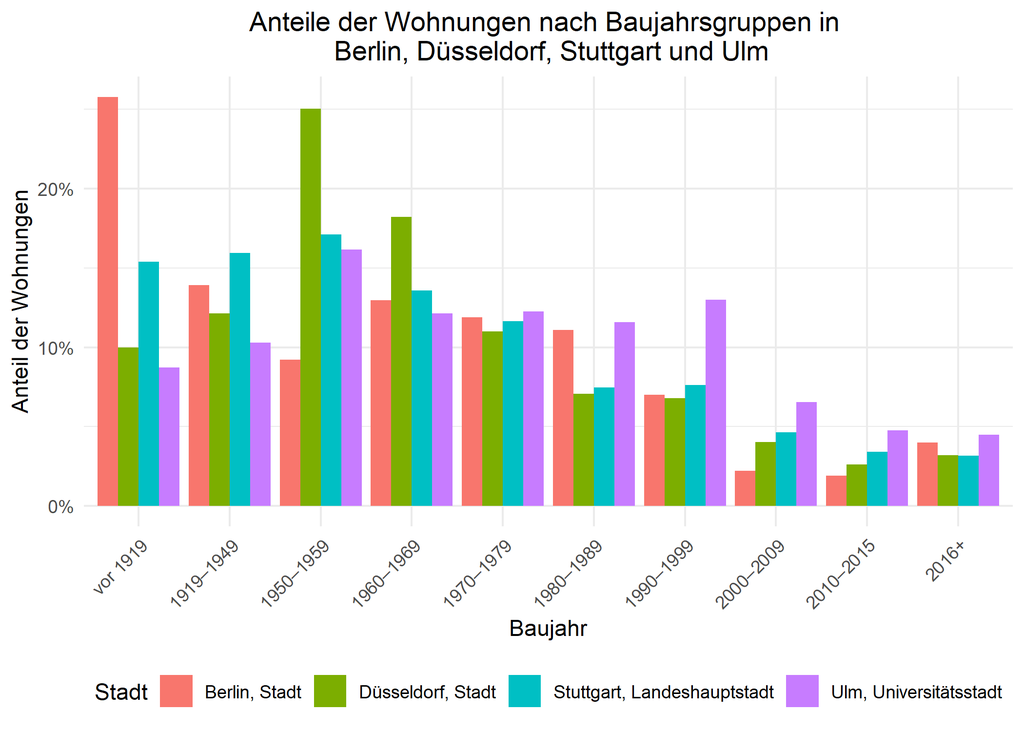

Die Grafik zeigt die Anteile von Wohnungen in den Städten Berlin, Düsseldorf, Stuttgart und Ulm, aufgeschlüsselt nach ihrem Baujahr. Auf der X-Achse sind die Baujahrsgruppen abgetragen, während die Y-Achse den jeweiligen Anteil der Wohnungen in Prozent darstellt.

Berlin hat in der Kategorie der Wohnungen vor 1919 mit über 25 % den mit Abstand höchsten Anteil. Ulm bildet in dieser Kategorie mit einem Anteil von weniger als 10 % das Schlusslicht.

Stuttgart verzeichnet mit etwa 16 % den höchsten Anteil an Wohnungen, die zwischen 1919 und 1949 errichtet wurden. Allerdings sind die Unterschiede zwischen den Städten in dieser Kategorie weniger ausgeprägt als bei den Wohnungen vor 1919.

In den Baujahrsgruppen 1950–1959 und 1960–1969 ist Düsseldorf Spitzenreiter, mit Anteilen von bis zu 25 %. Während Berlin in der Baujahrsgruppe 1950–1959 den geringsten Anteil aufweist, liegt Ulm in der Gruppe 1960–1969 am unteren Ende. Dies verdeutlicht den Fokus auf Wohnungsneubau in Düsseldorf während der wirtschaftlichen Boomjahre.

Die Anteile der Wohnungen, die zwischen 1970 und 1979 errichtet wurden, zeigen geringere Schwankungen und liegen bei allen Städten zwischen 10 % und 12 %. Ulm hat mit 12,3 % den höchsten Wert in dieser Kategorie. In den darauf folgenden Jahren (1980–1989 und 1990–1999) variieren die Anteile zwischen 4,5 % und 13 %.

In den jüngsten Baujahrsgruppen (2000–2009, 2010–2015 und 2016+) zeigt sich eine geringe Neubautätigkeit in allen Städten. Besonders Berlin verzeichnet mit etwa 2 % in der Kategorie 2010–2015 den niedrigsten Wert, während Ulm mit knapp 4,5 % etwas besser abschneidet. Dies deutet darauf hin, dass der Neubau in den letzten Jahrzehnten in den untersuchten Städten insgesamt zurückgegangen ist.

Die strukturellen Unterschiede zwischen den Städten sind deutlich erkennbar: Berlin, als Metropole mit vielen Altbauquartieren, weist logischerweise höhere Anteile in den frühen Baujahrsgruppen auf, während kleinere Städte wie Ulm einen größeren Anteil an moderneren Wohnbauten haben. Dies reflektiert nicht nur die historische Entwicklung, sondern auch die unterschiedlichen Wachstumsdynamiken der Städte.

Die relativ gleichmäßige Verteilung der Anteile zwischen 1950 und 1979 lässt sich durch die erhöhte Bautätigkeit nach dem Zweiten Weltkrieg erklären, die sowohl dem Wiederaufbau als auch dem wirtschaftlichen Aufschwung in dieser Zeit geschuldet war.

Ulm hat im Vergleich zu anderen Städten einen eher geringen Anteil an Wohnungen, die vor 1919 errichtet wurden. Dies ist nicht überraschend, da Ulm flächenmäßig relativ klein ist. Zudem wurde die Stadt im Zweiten Weltkrieg stark bombardiert, was zur Zerstörung vieler Gebäude aus der Zeit vor 1919 führte.

9. Wie in der vorherigen Aufgabe zu sehen war, unterscheidet sich die Situation in Städten in Bezug auf die jeweiligen Baujahre der Wohnungen deutlich. Es wäre noch spannend zu sehen, ob auch das Alter der Bewohner, die Familienstände, oder die Einwanderungshistorie der Bewohner mit unterschiedlichen Mietpreisen assoziiert sind. Hier sollen Sie in einem ersten generellen Schritt ein paar demografische Faktoren einbeziehen, inwiefern diese eine Auswirkung haben. Betrachten Sie folgende Eigenschaften genauer:
- Familienstand
- Alter der Bewohner
- Einwanderungsgeschichte

Erstellen Sie eine oder mehrere passende Diagramme oder Grafiken für die in Aufgabe 8 aufgeführten Städte.

Beschreiben und interpretieren Sie diese. Haben Sie diese Unterschiede erwartet? Begründen Sie warum oder warum nicht. Wo gibt es Ihrer Ansicht nach besondere Auffälligkeiten? Warum kann es bei der unterschiedlichen Einteilung der Altersgruppen zu Problemen kommen? Was wären Möglichkeiten, um etwaige Probleme zu vermeiden?

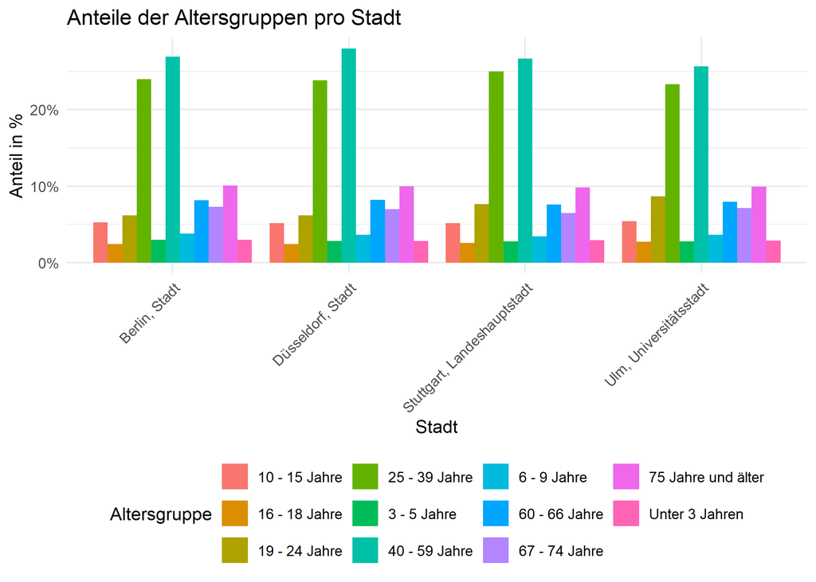

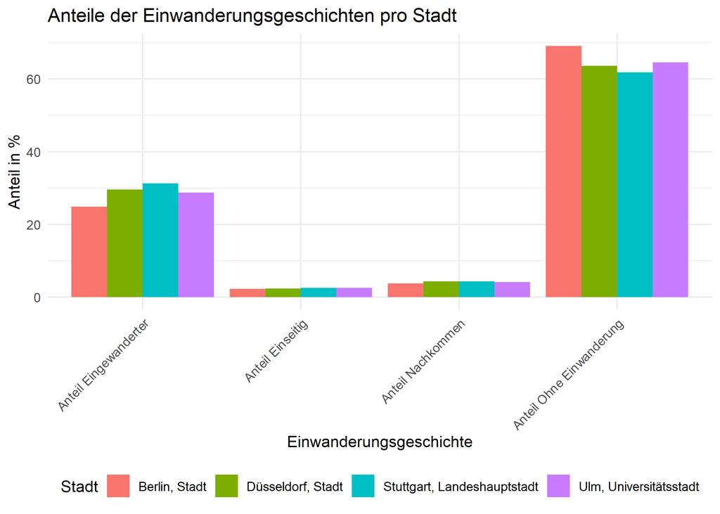

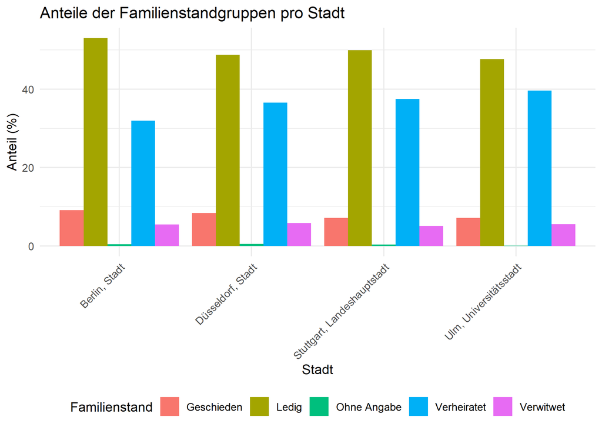

Die Verteilung der Altersgruppen in den einzelnen Städten ist sehr ähnlich, es gibt lediglich kleinere Abweichungen. Der Großteil der Bevölkerung in den Städten ist zwischen 25 und 59 Jahre alt. Die kleinste Gruppe bilden die 16- bis 18-Jährigen. Der demografische Wandel spiegelt sich in der Beobachtung wider: Der Anteil der 60- bis über 75-Jährigen (Baby-Boomer-Generation) ist in allen Städten besonders hoch. Im Gegensatz dazu ist der Anteil der jüngeren Generationen (Gen Z, Millennials, Generation Alpha) deutlich geringer. Interessant ist, dass der Anteil der Kinder unter 3 Jahren höher ist als der der 16- bis 18-Jährigen, was auf eine gestiegene Geburtenrate hindeuten könnte.

In allen Städten gibt es nur wenige Prozent, für die keine Angabe zum Familienstand vorliegt. Der Anteil an geschiedenen Personen liegt in allen Städten unter 10 %, wobei der höchste Anteil in Berlin zu finden ist. Der Anteil an verwitweten Personen beträgt in allen Städten etwa 5 %, mit äußerst geringen Abweichungen zwischen den Städten.

Der besonders hohe Anteil an ledigen Personen könnte darauf hindeuten, dass das Konzept der Ehe in der Gesellschaft nicht mehr denselben Stellenwert besitzt wie früher. Immer weniger Menschen entscheiden sich offenbar dafür zu heiraten, was einen Wandel in den gesellschaftlichen Normen widerspiegeln könnte.

In allen Städten gibt es nur wenige Prozent, für die keine Angaben zum Familienstand vorliegen. Der Anteil an geschiedenen Personen liegt in allen Städten unter 10 %, wobei der höchste Anteil in Berlin zu finden ist. Der Anteil an verwitweten Personen beträgt in allen Städten etwa 5 %, wobei die Abweichungen zwischen den Städten äußerst gering sind.

In den bisherigen Analysen wurden demografische und wohnungsbezogene Faktoren in verschiedenen Städten Deutschlands untersucht. Dabei lag der Fokus darauf, wie diese Merkmale in unterschiedlichen Regionen das Mietpreisniveau und dessen Struktur beeinflussen. Aufbauend auf diesen Erkenntnissen soll der Blick nun gezielt auf den Vergleich zwischen Ost- und Westdeutschland gelenkt werden. Diese regionale Differenzierung ermöglicht es, potenzielle Unterschiede und Gemeinsamkeiten zwischen den beiden Landesteilen genauer zu analysieren. Insbesondere wird betrachtet, wie sich die Mietpreisstruktur in Ost- und Westdeutschland darstellt und ob sich hierbei spezifische Muster oder Abweichungen erkennen lassen.

10. Betrachten Sie nun die Städte `Dresden, Stadt`, `Chemnitz, Stadt`, `Stuttgart, Landeshauptstadt`, `Ulm, Universitätsstadt`,`Düsseldorf, Stadt`und `Berlin, Stadt`. Vergleichen Sie in einem ersten Schritt die Anzahl an Einwohnern, den Anteil an Menschen, die deutscher Herkunft sind, den Anteil an neuen und alten Wohnungen, sowie die durchschnittlichen Mietpreise. Erweitern Sie ihre Analyse um die durschnittlichen Wohnflächen.

Erstellen Sie für die genannten Städte eine deskriptive Tabelle. Beschreiben und interpretieren Sie diese. Beantworten Sie insbesondere folgende Fragen:

- In wie weit könnte das Alter der Wohnungen eine Rolle für den Mietpreis spielen?
- Gibt es Auffälligkeiten zwischen den einzelnen Städten in Bezug auf Herkunft der Bewohner, Einwohner und Größe der Wohnungen?
- Warum könnte es problematisch sein, wenn Sie die Städte als ein Ganzes betrachten?
- Sind Ihre Ergebnisse auf die ganze Stadt verallgemeinerbar?
- Was sind ihrer Meinung nach Faktoren, die die unterschiedlichen Mietpreise in Ost und West erklären?
- Welche Maßnahmen wären geeignet, um in Düsseldorf, Ulm und Stuttgart die Mietpreisstruktur anzupassen und bezahlbaren Wohnraum zu schaffen?

| Stadt | Einwohnerzahl | Durchschnittlicher Mietpreis pro Quadratmeter | Durchschnittliche Wohnfläche | Anteil von Menschen mit deutscher Herkunft | Anteil neuer Wohnungen | Anteil alter Wohnungen |
| --- | --- | --- | --- | --- | --- | --- |
| Düsseldorf, Stadt | 611258 | 9.24 | 77.56 | 77.24 | 5.78 | 22.11 |
| Stuttgart, Landeshauptstadt | 610458 | 10.39 | 79.76 | 74.30 | 6.57 | 31.33 |
| Dresden, Stadt | 557782 | 6.92 | 71.24 | 90.69 | 6.62 | 39.61 |
| Chemnitz, Stadt | 240078 | 5.26 | 71.33 | 90.23 | 3.18 | 41.03 |
| Ulm, Universitätsstadt | 127116 | 8.48 | 87.64 | 78.22 | 9.26 | 19.02 |

Auffällig ist, dass der Anteil an Menschen mit deutscher Herkunft in ostdeutschen Städten deutlich höher ist als in westdeutschen Städten. Hierbei spielen kulturelle und historische Unterschiede eine wesentliche Rolle.

Ein weiterer auffälliger Unterschied zwischen Ost- und Westdeutschland ist der deutlich höhere Anteil alter Wohnungen in ostdeutschen Städten.

Diese Analyse verdeutlicht die großen Unterschiede zwischen Ost- und Westdeutschland. Ein aggregierter Vergleich aller Städte würde diese Unterschiede verwischen und zu einem verzerrten Bild führen. Beispielsweise würden die stark divergierenden Verhältnisse zwischen Chemnitz und Düsseldorf weniger deutlich werden.

Um bezahlbaren Wohnraum in Städten wie Düsseldorf, Stuttgart und Ulm zu schaffen, könnten Maßnahmen wie eine verstärkte Förderung des Sozialwohnungsbaus durch steuerliche Anreize oder Zuschüsse helfen. Dies würde Investoren motivieren, in Projekte zu investieren, die auf erschwingliche Mietwohnungen abzielen.

11. Lesen Sie den [folgenden Artikel](https://www.tagesschau.de/wirtschaft/sozialwohnungen-bau-mangel-101.html). Dort werden Sozialwohnungen thematisiert, warum so viele fehlen und wer davon vor allem betroffen ist. Beantworten Sie anschließend folgende Fragen:
- Welche Bevölkerungsgruppen sind am stärksten von der Sozialwohnungsnot betroffen und inwiefern?
- Was sind Gründe, warum es zu wenige Sozialwohnungen gibt?
- Wie sieht die historische Entwicklung des Sozialwohnungsbaus aus, im Hinblick auf Vorhandensein von Wohnungen und Investitionen in den Bau von neuen Wohnungen?
- Welche Anreize könnten Investoren motivieren, mehr Sozialwohnungen zu bauen?
- Welche innovativen Ansätze können Bauherren verfolgen, um die Kosten für den Wohnungsbau zu senken?
- Am stärksten von der Sozialwohnungsnot betroffen sind unter anderem Familien, die in finanzielle Schieflage geraten sind. Auch Menschen mit geringem Einkommen, Alleinerziehende und Senioren sind stark vom Mangel an Sozialwohnungen betroffen. Besonders schwierig ist die Situation für Menschen mit einem Wohnberechtigungsschein, da die Wartelisten lang sind und oft keine freien Wohnungen zur Verfügung stehen.
- Der Bau von Sozialwohnungen hat in den letzten Jahrzehnten für Investoren zunehmend an Attraktivität verloren. Gründe dafür sind die gestiegenen Baukosten sowie langwierige Genehmigungsverfahren. Hinzu kommt, dass der Bau von Sozialwohnungen Ländersache ist, was die Umsetzung neuer Projekte zusätzlich erschwert, da je nach Bundesland unterschiedliche Vorschriften und Förderkonditionen gelten. In teuren Städten ist der marktwirtschaftliche Gewinn auf dem freien Wohnungsmarkt deutlich höher, was Investoren oft dazu bewegt, diesen vorzuziehen.
- In den 1990er Jahren gab es in Deutschland noch rund 3 Millionen Sozialwohnungen. Heute sind es nur noch etwa 1,1 Millionen. Dieser Rückgang ist unter anderem darauf zurückzuführen, dass viele Wohnungen nach Ablauf der Mietbindung aus der Sozialförderung herausfallen. Weitere Gründe für den Rückgang waren die Reduzierung staatlicher Fördermittel für den Sozialwohnungsbau.
- Eine stärkere staatliche Förderung und die Umsetzung des Modells der sogenannten “Wohngemeinnützigkeit”, bei dem Unternehmen Steuervorteile erhalten, wenn sie Wohnungen zu günstigen Preisen anbieten, könnten die Attraktivität des Sozialwohnungsbaus steigern. Auch der Abbau bürokratischer Hürden und die damit einhergehende Vereinfachung der Genehmigungsverfahren wären wichtige Schritte, um Investoren zu motivieren.
- Um die Kosten für den Wohnungsbau zu senken, könnten Bauherren auf innovative Bauweisen wie den Holzbau setzen. Der Bau kleinerer Treppenhäuser und Flachdächer ohne Attika* kann ebenfalls die Ausgaben reduzieren. Durch die gezielte Zuwanderung von Fachkräften aus dem Ausland könnte der Fachkräftemangel im Bauwesen gelindert werden, was langfristig zu stabileren und niedrigeren Baukosten führt.

> *Erhöhtes Bauelement, welches am Rand eines Daches verläuft.
12. Gerade die Politik ist gefordert, bezahlbaren Wohnraum zu realisieren. Dabei gibt es eine Viezahl an politischen Maßnahmen, die aufgestellt wurden und umfangreich diskutiert werden. Betrachten Sie die folgenden Maßnahmen, welche helfen sollen, die angespannte Lage auf dem Mietmarkt zu entlasten. Argumentieren Sie, warum diese Maßnahmen sinnvoll/nicht sinnvoll sind und in welcher Art und Weise diese umgesetzt werden können.
1. “Fachleute fordern, die Regulierung von Bestandsmieten zu lockern, damit sich ihr Niveau den Neuvertragsmieten annähert, mehr Menschen umziehen und sich Wohnraum besser verteilt.”
2. “Eine weitere Möglichkeit wäre, Mieterhöhungen bei Neuvertragsmieten zu begrenzen.”
3. “Am einfachsten ist es, wenn vor allem in Großstädten, wo bezahlbarer Wohnraum fehlt, mehr gebaut wird.”
4. “Am besten wäre es, wenn zukünftig mehr Vermieter in regelmäßigen Abständen die Miete anpassen.”

Vorteile:

- Wohnräume, die nicht effizient genutzt werden, könnten freigegeben werden. So können Familien, die in zu kleinen Wohnungen leben in größere ziehen und ältere Generationen, die sich einen kleineren Wohnraum verschaffen wollen, in kleinere Immobilien ziehen.Somit könnten also WOhnräume besser genutzt werden. +Eine Lockerung könnte langfristig eine Angleichung von Mieten bewirken und somit den Markt effizienter gestalten.

Nachteile:

-Haushalte mit niedrigerem Einkommen, die auf günstige Bestandsmieten angewiesen sind, könnten sich durch höhere Mieten, Wohnungen finanziell nicht leisten. -Eine Lockerung könnte zu weiteren Mieterhöhungen führen, da Vermieter Bestandsmieten rasch anpassen könnten

=Vermieter dürfen die Miete bei Bestandsmietern nur dann stärker anheben, wenn konkrete Modernisierungen oder Verbesserungen der Wohnqualität vorgenommen werden

Laut Ökonoemen könnte dies die Lage auf dem Wohnugnsmarkt nurnoch verschlechtern.Eine Begrenzung von Mieterhöhungen bei Neuvertragsmieten könnte dazu führen, dass weniger Wohnugen zur Miete angeboten werden. Für Vermieter könnte es somit attraktiver erscheinen Ihren Wohnungen als Ferienwohnugen anzubieten. Desweiteren könnte dies dazu führen, dass Vermieter ihre Wohnugen nur an diejenigen vergeben, welche bereit dazu sind “schwarz” mehr zu bezahlen. =In Städten mit besonders angespannter Lage könnten Mieterhöhungsgrenzen zeitlich begrenzt verschärft werden, um den Markt zu stabilisieren.

Vorteile:

- Ein erhöhtes Angebot an Wohnraum würde die Mietpreise senken. Besonders in Großstädten, wo die Nachfrage hoch ist, ist dies eine zentrale Maßnahme.
- Der Bau neuer Wohnungen schafft Arbeitsplätze und kurbelt die Bauwirtschaft an.

Nachteile:

-Wohnungsbau ist zwar eine langfristige Lösung aber es könnte Genehmigungsverfahren und Grundstücksverfügbarkeit den Prozess verzögern. - Der Bau neuer Wohnungen ist teuer.Die Mietpreise der Neubauten könen dennoch hoch bleiben. =Leerstehende Bürogebäude oder nicht mehr genutzte Gewerbeflächen könnten in Wohnraum umgewandelt werden. Das spart Zeit und Ressourcen.

Vorteile:

- Regelmäßige Anpassungen in kleineren Schritten könnten sowohl für Vermieter als auch für Mieter besser sein, anstatt plötzlicher und drastischer Mietsteigerungen.
- Vermieter könnten eher geneigt sein, Wohnungen regelmäßig zu modernisieren oder instand zu halten, wenn sie die Miete in kleinen, transparenten Schritten erhöhen können.

Nachteile:

-Auch kleine, regelmäßige Anpassungen könnten für Haushalte mit niedrigem Einkommen problematisch werden, wenn sie sich summieren. =Vermieter könnten verpflichtet werden, Anpassungen in kleinen, kalkulierbaren Schritten durchzuführen, um plötzliche Belastungen für Mieter zu vermeiden.Eine regelmäßige Anpassung sollte nur erlaubt sein, wenn der Vermieter den Wohnstandard verbessert.

# Einzelne Stadtteile in Deutschland

In allen vorherigen Aufgaben haben Sie die Städte, Gemeinden oder auch Landkreise immer als ein Ganzes betrachtet. Jedoch ist es schwierig gerade in Großstädten wie Berlin, Düsseldorf oder auch Stuttgart allgemeine Aussagen über die Mietsituation auf Stadtebene zu treffen. Dies liegt unter anderem daran, dass unterschiedliche Stadtviertel unterschiedliche demografische Eigenschaften, sowie eine unterschiedliche Mietstruktur aufweisen können. Hier wäre es sinnvoll sich mit dem Stadtbild und der Verteilung der Mieten genauer auseinanderzusetzen, um zu sehen, wie sich Mieten innerhalb der Stadt verteilen. Wie in Aufgabe 10 zu sehen war, weisen die Städte im Westen Deutschlands untereinander, sowie die Städte im Osten ähnliche Merkmale auf, weshalb Sie sich in den folgenden Aufgaben auf je eine große und eine kleinere Stadt aus beiden Regionen konzentrieren.

13. In dieser Aufgabe sollen Sie ihren Datensatz aus Aufgabe 4, bei dem Sie Kartendaten und Informationen zu Mieten und LEQ auf 1km-Gitterebene heruntergeladen und zusammengefügt haben, verwenden und vier Karten zeichnen, welche die Verteilung der Nettokaltmieten in den Stadtteilen der Städte “Stuttgart, Landeshauptstadt”, “Ulm, Universitätsstadt”, “Chemnitz, Stadt” und “Dresden, Stadt” anschaulich visualisieren.

Erstellen Sie vier Grafiken, beschreiben und interpretieren diese. Gehen Sie insbesondere auf folgende Fragen ein:

- Welche Besonderheiten fallen Ihnen bei diesen Städten auf?
- Gibt es eine Segregation in Bezug auf die Mieten in einzelnen Stadtteilen?
- Falls es eine Segregation gibt, welche Konsequenzen könnte dies haben?
- Welche Rolle spielen geografische oder infrastrukturelle Faktoren bei den Mietpreisen?
- Gibt es Unterschiede zwischen Städten im Osten und Westen Deutschlands, falls ja, welche Einflüsse in Bezug auf Wirtschaft und Arbeitsmarkt könnte dies in den jeweiligen Städten haben?

*Hinweis:* Wenn Sie einheitliche Legenden für die Karten haben möchten und die vier Städte nebeneinander oder untereinander darstellen wollen, so empfiehlt sich das Paket `ggpubr` und dort der Befehl `ggarrange`.

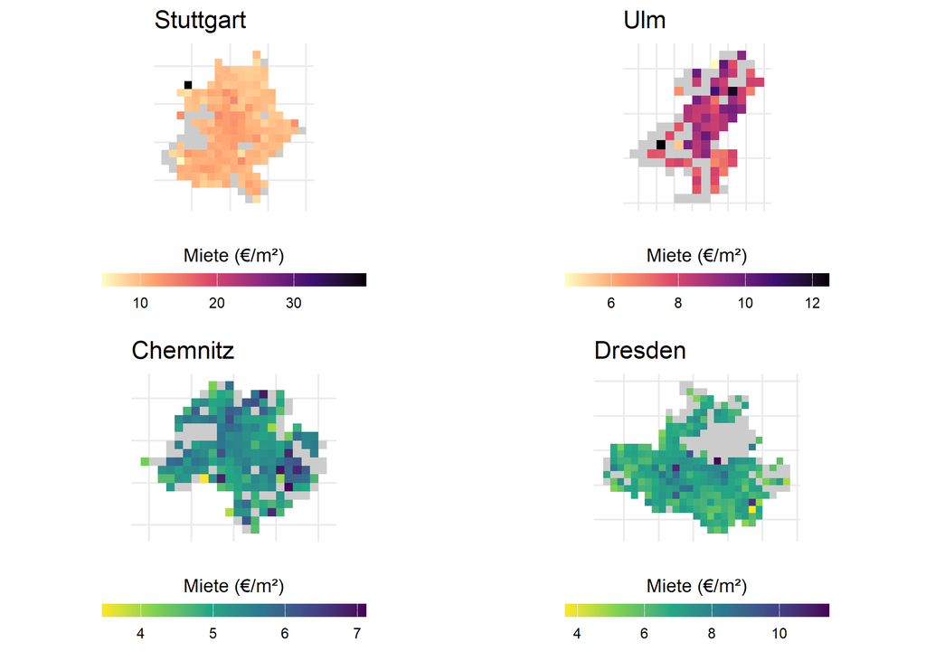

Zu erkennen ist ein deutliches Ost-West-Gefälle zwischen den Städten Stuttgart, Ulm, Dresden und Chemnitz.

Dresden weist ein ähnliches Niveau wie Chemnitz auf, mit Preisen zwischen 4 und 10 Euro pro m². In der Innenstadt ist das Wohnen tendenziell am teuersten, während die Randbezirke erschwinglicher sind.

14. Nachdem Sie in Aufgabe 13 die Verteilung der Mieten der einzelnen Stadtteile visualisiert haben, sollten Sie in dieser Aufgabe den Anteil der Leerstandsquoten in den Stadtteilen der Städte “Stuttgart, Landeshauptstadt”, “Ulm, Universitätsstadt”, “Chemnitz, Stadt” und “Dresden, Stadt” veranschaulichen.

Erstellen Sie vier Grafiken, beschreiben und interpretieren diese. Gehen Sie insbesondere auf folgende Fragen ein:

- Was könnten Gründe sein, dass die Leerstandsquote in bestimmten Stadtteilen höher ist, als in anderen?
- Welche Besonderheiten fallen Ihnen bei diesen Städten auf? Auch im Hinblick auf ihre Erkenntnisse aus Aufgabe 13.
- Vergleichen Sie die Grafiken aus Aufgabe 13 und Aufgabe 14. Was könnte der Grund für die unterschiedlichen Muster sein?
- Welche Maßnahmen ergreifen Städte mit hohen Leerstandsquoten, um diese zu reduzieren?

*Hinweis:* Wenn Sie einheitliche Legenden für die Karten haben möchten und die vier Städte nebeneinander oder untereinander darstellen möchten, so empfiehlt sich das Paket `ggpubr` und dort der Befehl `ggarrange`.

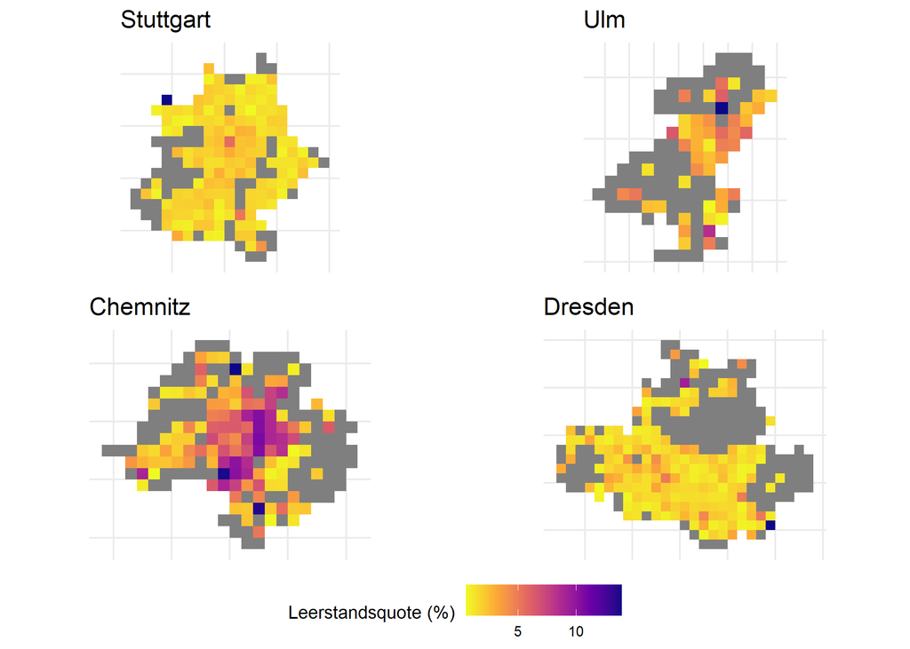

Die Leerstandsquote in Stuttgart zeigt ein homogenes Bild mit sehr niedrigen Werten, die sich überwiegend zwischen 0 und 5 % bewegen. In vereinzelten Bereichen überschreitet die Quote leicht 5 %. Dieses Muster korreliert mit den Erkenntnissen aus der Mietpreisanalyse: Die hohe Nachfrage nach Wohnraum in Stuttgart sorgt für eine geringe Anzahl leerstehender Immobilien, insbesondere in zentralen und gut angebundenen Stadtteilen.

In Ulm sind aufgrund von fehlenden Daten keine umfassenden Aussagen möglich. Dennoch lässt sich erkennen, dass die Leerstandsquote insgesamt niedrig ist, ähnlich wie in Stuttgart. Eine Ausnahme bildet ein Bereich im Norden, in dem die Quote bei über 10 % liegt. Die geringe Leerstandsquote in anderen Bereichen weist auf eine stabile Nachfrage nach Wohnraum hin, wobei die fehlenden Daten Lücken in der Interpretation hinterlassen.

Auch in Dresden ist die Leerstandsquote überwiegend homogen und bewegt sich, ähnlich wie in Stuttgart, zwischen 0 und 5 %. Eine Ausnahme bildet ein nördlicher Stadtteil, in dem die Quote etwa 8 % beträgt. Für Loschwitz, ein Villenviertel, fehlen ebenfalls Daten, doch aufgrund der gehobenen Wohnstruktur ist ein niedriger Leerstand zu vermuten. Die homogene Verteilung der Leerstände in Dresden deckt sich weitgehend mit den Ergebnissen der Mietpreisanalyse, da auch hier die zentrumsnahen Bereiche eine stabile Nachfrage zeigen.

Chemnitz zeigt ein heterogenes Bild der Leerstandsquote. Insbesondere in zentralen Stadtteilen wie Zentrum, Kaßberg und Lutherviertel liegt die Quote bei über 10 %, was auf eine geringe Nachfrage in diesen Bereichen hinweist. In den Randbezirken ist der Leerstand tendenziell geringer, wobei auch hier Datenlücken eine vollständige Analyse erschweren. Die Leerstandsquote in Chemnitz unterscheidet sich signifikant von den anderen Städten und deutet auf strukturelle Herausforderungen wie wirtschaftliche Schwäche oder Abwanderung hin.

15. Die aktuellen Mietpreise und deren Entwicklungen hindern in Deutschland immer mehr Menschen daran, dass sie sich eine neue geeignete Wohnung suchen. Personen, die aufgrund ihrer aktuellen Lebenssituation sich nach einer neuen Wohnung umsehen, finden oft keine oder können sich diese nicht leisten. Doch worin liegen die Ursachen und Probleme?

Beantworten Sie hierzu folgende Fragen:

- Was versteht man unter dem Lock-in-Effekt, speziell in Bezug auf den Mietmarkt? Wer ist davon vor allem betroffen und warum?
- Gibt es aktuell Möglichkeiten, die vor allem diese “betroffenen” Personen haben, um an bezahlbaren Wohnraum zu gelangen?
- Worin liegen die Ursachen, dass Bestandsmieten (Mieten aus bestehenden Verträgen) und Angebotsmieten (Mieten aus Neuverträgen) so stark voneinander abweichen?

Gehen Sie in ihrer Argumentation auch auf die Grafiken und Ergebnisse der Aufgaben 11, 13 und 14 ein.

- Der sogenannte Lock-in-Effekt beschreibt das Phänomen, dass ältere Menschen nach dem Auszug ihrer Kinder oft in zu großen Wohnungen mit vergleichsweise günstigen Mieten wohnen bleiben. Ein Umzug in eine kleinere Wohnung ist für sie finanziell nicht machbar, da die Miete für eine neue, kleinere Wohnung oft deutlich höher wäre. Diese Menschen sind somit “eingesperrt” in ihrer aktuellen Wohnsituation. Neben älteren Menschen sind auch Alleinerziehende oder Familien mit geringem Einkommen betroffen, da sie aufgrund begrenzter finanzieller Mittel und hohem Betreuungsaufwand nicht die Ressourcen haben, umzuziehen.
- Eine Möglichkeit, für diese Menschen an bezahlbaren Wohnraum zu gelangen, ist der Wohnungstausch. Zusätzlich bieten staatliche Förderungen wie Wohngeld Unterstützung. Städte könnten außerdem Maßnahmen zur Aktivierung von Leerständen umsetzen, um das Wohnungsangebot zu erhöhen.
- Die Ursachen für stark abweichende Bestands- und Angebotsmieten liegen unter anderem darin, dass Bestandsmieten nur geringen Anpassungen unterworfen sind. Gleichzeitig wächst die Bevölkerung, während weniger neuer Wohnraum entsteht. Diese Knappheit führt zu steigenden Mietpreisen auf dem freien Markt.

# Stadt vs. Land

Bisher haben Sie sich intensiv mit der Wohnsituation in Deutschland auseinandergesetzt und dabei insbesondere die Unterschiede zwischen Ost- und Westdeutschland betrachtet. Im Fokus standen dabei die Mietpreisentwicklung und die Rolle verschiedener Faktoren wie demografische Merkmale, Leerstandsquote, Eigentümerquote, sowie die Wohnfläche. Diese Analysen haben wertvolle Erkenntnisse über die regionale Dynamik des Mietmarkts geliefert.

Nun sollen Sie ihren Blickwinkel erweitern und den Fokus auf eine weitere Ebene der Analyse richten. Im Kern sollen Sie den Unterschied zwischen städtischen Regionen, insbesondere Großstädten, und ländlichen Gebieten untersuchen. Hierbei soll die Mietstruktur in diesen beiden Raumtypen analysiert werden, ob sich die Strukturen von Stadt und Land voneinander unterscheiden.

16. Betrachten Sie in einem ersten Schritt die Wohnungen abhängig ihres Alters. Erstellen Sie dazu eine passende Grafik, die die Verteilung der Wohnungen nach Altersgruppen für die Stadt `Stuttgart, Landeshauptstadt` (Landkreis: Stuttgart, Stadtkreis) im Vergleich zum `Alb-Donau-Kreis` und `Ostalbkreis` darlegt.

Beschreiben und interpretieren Sie ihre Grafik. Woran könnte es liegen, dass es in Stuttgart (in der Stadt) deutlich mehr Altbauwohnungen als auf dem Land gibt? Könnten politische Maßnahmen ihrer Ansicht nach helfen, dass auch in Großstädten mehr neue Wohnungen erbaut und zur Vermietung zur Verfügung gestellt werden?

*Hinweis 1:* Nutzen Sie für die Visualisierung einen Mosaik- oder ein “stacked” Balkendiagramm. Eine Idee, wie Sie das Ganze darstellen können, finden Sie [hier](https://r-graph-gallery.com/).

*Hinweis 2:* Für Stuttgart soll der komplette Landkreis (“Stadtkreis”) untersucht werden.

[figure not shown]

Der Grafik lässt sich entnehmen, dass Stuttgart tatsächlich einen deutlich höheren Anteil an Altbauwohnungen aufweist als ländlichere Regionen wie der Alb-Donau-Kreis und der Ostalbkreis. Dies könnte unter anderem auf den Denkmalschutz zurückzuführen sein. Viele Gebäude in Stuttgart stehen unter Schutz und können daher nicht ohne Weiteres abgerissen oder durch Neubauten ersetzt werden. Darüber hinaus hat der Mangel an verfügbaren Bauflächen in der Stadt dazu geführt, dass der Fokus eher auf der Renovierung und Modernisierung der bestehenden Bausubstanz lag, während Neubauprojekte seltener realisiert wurden. Zudem wurden viele Flächen in Stuttgart für andere Zwecke, wie Industrie- oder Infrastrukturprojekte, genutzt, was den verfügbaren Raum für Wohnungsbau weiter eingeschränkt hat.

Im Gegensatz dazu bieten die Gemeinden des Alb-Donau-Kreises und des Ostalbkreises deutlich größere Flächenpotenziale für den Wohnungsbau. Die geringere Bevölkerungsdichte und die Verfügbarkeit von ungenutzten Bauflächen ermöglichen es, Neubauprojekte schneller und einfacher umzusetzen. Dies erklärt, warum in diesen ländlichen Regionen ein höherer Anteil an neueren Wohnungen zu finden ist. Gleichzeitig reflektiert dies die unterschiedlichen Prioritäten und Möglichkeiten zwischen städtischen und ländlichen Gebieten.

Um den Wohnraummangel in Stuttgart und anderen Großstädten zu bekämpfen, könnten gezielte politische Maßnahmen helfen. Dazu gehören die Ausweisung neuer Bauflächen, die Umnutzung brachliegender Industrieareale sowie eine stärkere Nachverdichtung in bestehenden Quartieren. Förderprogramme für energieeffiziente Neubauten könnten Investitionen attraktiver machen und langfristig die Wohnraumsituation in Städten wie Stuttgart verbessern.

In einem weiteren Schritt sollen Sie nun die Mietpreise und deren Verteilung analysieren. Hierbei sollen Sie neben der Leerstands- und Eigentümerquote auch auf die Verteilung der Wohnungen nach deren Wohnfläche achten und diese untersuchen.

17 (a). Erstellen Sie zuerst eine Tabelle, die die durchschnittlichen Mietpreise mit der Leerstands- und Eigentümerquote darstellt. Was fällt ihnen dabei besonders auf? Beschreiben und interpretieren Sie ihre Tabelle.

17 (b). Erstellen Sie eine weitere Grafik, die die Verteilung der Wohnungen nach den einzelnen Wohnungsgrößen(<40m² bis >=200m²) abbildet. Stellen Sie darüber hinaus den durchschnittlichen Mietpreis je Landkreis in einer weiteren Grafik dar. Beschreiben und interpretieren Sie ihre Grafiken. Gehen Sie insbesondere auf die Frage ein, ob es Sinn macht sich vor allem den Ostalbkreis oder Alb-Donau-Kreis als ein Ganzes anzusehen und inwieweit überhaupt ein Vergleich zwischen Stadt und ländlicher Region möglich ist.

*Hinweis:* Hier sollen Sie erneut auf dieselben Städte und Landkreise aus Aufgabe 16 eingehen!

| Landkreis | Durchschnittliche Leerstandsquote(%) | Durchschnittliche Eigentümerquote (%) | Durchschnittlicher Mietpreis pro m²(€) |
| --- | --- | --- | --- |
| Alb-Donau-Kreis | 5.34 | 71.44 | 6.37 |
| Ostalbkreis | 5.09 | 70.59 | 6.27 |
| Stuttgart, Stadtkreis | 3.46 | 31.15 | 10.39 |

Die vorliegende Tabelle veranschaulicht die durchschnittliche Leerstands- und Eigentümerquote sowie den durchschnittlichen Mietpreis pro Quadratmeter für den Alb-Donau-Kreis, den Ostalbkreis und den Stadtkreis Stuttgart. Die Werte verdeutlichen signifikante Unterschiede zwischen den Landkreisen und dem städtischen Raum, insbesondere im Hinblick auf die Eigentumsstrukturen und Mietpreise.

In Stuttgart liegt die Leerstandsquote bei lediglich 3,46 %, was auf eine starke Nachfrage nach Wohnraum hinweist. Im Vergleich dazu zeigen die beiden ländlicheren Landkreise, der Alb-Donau-Kreis (5,34 %) und der Ostalbkreis (5,09 %), höhere Leerstandsquoten. Dies könnte darauf hindeuten, dass in ländlichen Regionen Wohnungen schwieriger zu vermieten sind, möglicherweise bedingt durch weniger starke Bevölkerungszuwächse oder geringere Nachfrage.

Die Eigentümerquote zeigt ebenfalls deutliche Unterschiede: Während Stuttgart eine vergleichsweise niedrige Eigentümerquote von 31,15 % aufweist, liegt diese in den Landkreisen Alb-Donau-Kreis (71,44 %) und Ostalbkreis (70,59 %) deutlich höher. Dies ist ein typisches Muster, das darauf hindeutet, dass in ländlichen Regionen der Erwerb von Wohneigentum traditionell bevorzugt wird und finanziell leichter realisierbar ist, während in Städten wie Stuttgart Mietwohnungen dominieren, bedingt durch hohe Immobilienpreise und die Mobilität der Bevölkerung.

Der Mietpreis pro Quadratmeter zeigt die deutlichsten Unterschiede: Während die Mietpreise in den Landkreisen Alb-Donau-Kreis (6,37 €) und Ostalbkreis (6,27 €) vergleichsweise moderat sind, liegt der Durchschnittspreis in Stuttgart bei 10,39 €.

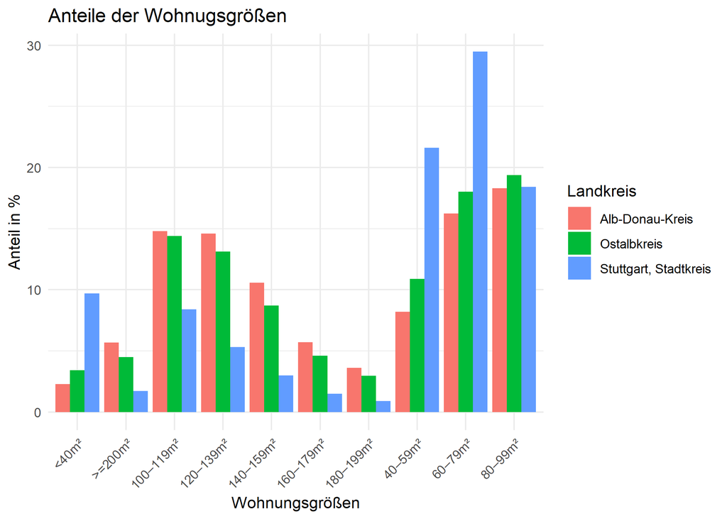

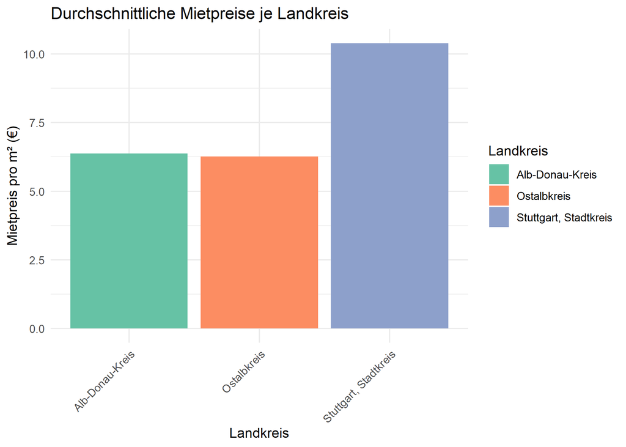

Stuttgart weist einen hohen Anteil an kleinen Wohnungen auf, wobei knapp 10 % der Wohnungen weniger als 40 m² groß sind. Große Wohnungen (≥ 200 m²) sind in Stuttgart äußerst selten, mit einem Anteil von nur etwa 2 %. Dieser deutliche Fokus auf kleinere und mittelgroße Wohnungen spiegelt die hohe Nachfrage nach kompakterem Wohnraum in einer dicht besiedelten städtischen Umgebung wider.

Im Vergleich dazu liegt das Mietpreisniveau im Alb-Donau-Kreis und im Ostalbkreis deutlich niedriger. Während die Mietpreise in diesen Landkreisen bei etwa 6 bis 6,5 € pro Quadratmeter liegen, beträgt der durchschnittliche Mietpreis in Stuttgart etwa 10,4 € pro Quadratmeter. Dies unterstreicht die erheblichen Preisunterschiede zwischen der Großstadt und den ländlichen Regionen, die durch Faktoren wie höhere Grundstückskosten, begrenzte Flächen und eine stärkere Nachfrage in Stuttgart bedingt sind.

Hinsichtlich des Mietpreisniveaus kann es sinnvoll sein, den Alb-Donau-Kreis und den Ostalbkreis als Einheit zu betrachten. Bezüglich des Anteils an Wohnungen unterschiedlicher Größen gibt es zwar Unterschiede zwischen den beiden Landkreisen, diese sind jedoch vergleichsweise gering. Im Gegensatz dazu sind die Unterschiede zwischen Stuttgart und den beiden Landkreisen deutlich größer, insbesondere was den Wohnraumanteil und das Mietpreisniveau betrifft.

Ein direkter Vergleich zwischen Stadt und Land ist zwar möglich, erfordert jedoch die Berücksichtigung verschiedener Aspekte. Städte wie Stuttgart zeichnen sich durch kleinere Wohnungen und eine hohe Nachfrage nach Wohnraum aus, was oft mit höheren Mietpreisen einhergeht. In ländlichen Regionen hingegen sind Wohnungen tendenziell größer, während die Mietpreise deutlich niedriger ausfallen.

Auch die Infrastruktur unterscheidet sich grundlegend: Während in Städten der öffentliche Nahverkehr gut ausgebaut ist, sind Bewohner ländlicher Gebiete häufig auf das Auto angewiesen.

Ein weiterer Unterschied zeigt sich im sozialen Leben. Auf dem Land ist der Zusammenhalt innerhalb der Gemeinschaft oft stark ausgeprägt, während in Großstädten das Leben anonymer gestaltet ist. Allerdings bieten Städte auch vielfältige soziale und kulturelle Netzwerke, die in ländlichen Gebieten weniger ausgeprägt sind.

# Zusatzfrage (optional)

Diese Frage ist von der Bearbeitung her etwas schwieriger. Bevor Sie sich an diese Aufgabe machen, sollten Sie sicherstellen, dass Sie alle vorherigen Fragen ausführlich beantwortet haben. Eine korrekte Beantwortung dieser Frage gibt einen Punktebonus von 3 Punkten (das Projekt umfasst insgesamt 30 Punkte, inkl. Screencast).

Nachdem Sie sich in den bisherigen Aufgaben ausführlich mit den allgemeinen Einflussfaktoren auf die Mietpreise befasst haben, rückt nun ein spezifischer Aspekt in den Fokus: die Rolle der Heizungen. Insbesondere werden Sie untersuchen, wie unterschiedliche Heizungsarten und -systeme die Mietpreise beeinflussen können. Diese Betrachtung ermöglicht es ihnen, die bisherigen Analysen zu verfeinern und den Zusammenhang zwischen energetischen Standards und der Entwicklung von Mietkosten genauer zu erfassen. Aufgabe 18 führt Sie somit zu einem weiteren zentralen Detail der Mietpreisentwicklung, das insbesondere vor dem Hintergrund steigender Energiepreise und der Relevanz nachhaltiger Wohnformen an Bedeutung gewinnt.

18. Lesen Sie den Datensatz `Heiztypen_Zensus.csv` ein und speichern diesen als `heiztypen` ab. Neben den Ihnen bekannten Variablen, finden Sie dort 6 weitere Variablen, die Auskunft über die Heizarten der jeweiligen Wohnung geben. Diese werden wie folgt beschrieben:
- HEIZTYP__1: Gebäude mit Heizungsart Fernheizung (Fernwärme) (Anzahl)
- HEIZTYP__2: Gebäude mit Heizungsart Etagenheizung (Anzahl)
- HEIZTYP__3: Gebäude mit Heizungsart Blockheizung (Anzahl)
- HEIZTYP__4: Gebäude mit Heizungsart Zentralheizung (Anzahl)
- HEIZTYP__5: Gebäude mit Heizungsart Einzel- oder Mehrraumöfen (auch Nachtspeicherheizung) (Anzahl)
- HEIZTYP__6: Gebäude mit Heizungsart Keine Heizung im Gebäude oder in den Wohnungen (Anzahl)

Erstellen Sie eine neue Spalte `heiztypen_gesamt`, welche die Summe über alle Heiztypen hinweg bildet. Bestimmen Sie weiterhin den Anteil der jeweiligen Heiztypen je Gemeinde (als Anteil aller Heizarten). Nun sollen Sie eine oder mehrere passende Grafik(en) erzeugen, die je nach durchschnittlicher Größe der Wohnungen die Anteile der verschiedenen Heizungsarten abbilden. Erstellen Sie weiterhin eine oder mehrere passende Grafik(en) die den Zusammenhang zwischen den Heizungsarten und den durschnittlichen Mietpreisen darstellt. Wiederum soll der Anteil der verschiedenen Heizungsarten abhängig der Mietpreise abgebildet werden. ——

Beschreiben und interpretieren Sie ihre Schaubilder und gehen Sie insbesondere auf folgende Frage ein:

- Gibt es einen Zusammenhang zwischen der Heizungsart und der Größe der Wohnungen?
- Gibt es einen Zusammenhang zwischen der Heizungsart und den Mietpreisen?
- Was könnten Gründe sein, warum in bestimmten Wohnungsgrößen eher bestimmte Heizungstypen eingebaut werden und andere nicht?
- Warum könnte es sein, dass bei manchen Heizungsarten die Mietpreise höher sind als bei anderen?
- Was könnte die Bundesregierung machen, um trotz neuer und moderner Heizungssysteme die Mietpreise nach oben hin zu beschränken?

*Hinweis 1:* Überlegen Sie sich, ob es ihrer Ansicht nach Sinn macht, die jeweiligen Wohnungsgrößen und durchschnittlichen Mietpreise in Segmente zu unterteilen.

*Hinweis 2:* Eine Möglichkeit die Beziehung zwischen Heizungsarten und Wohnungsgrößen bzw. Heizungsarten und Mietpreisen zu visualisieren wäre beispielsweise ein “stacked” oder “grouped” Balkendiagramm. Überlegen Sie sich, warum diese Form der Darstellung besonders gut geeignet wäre.

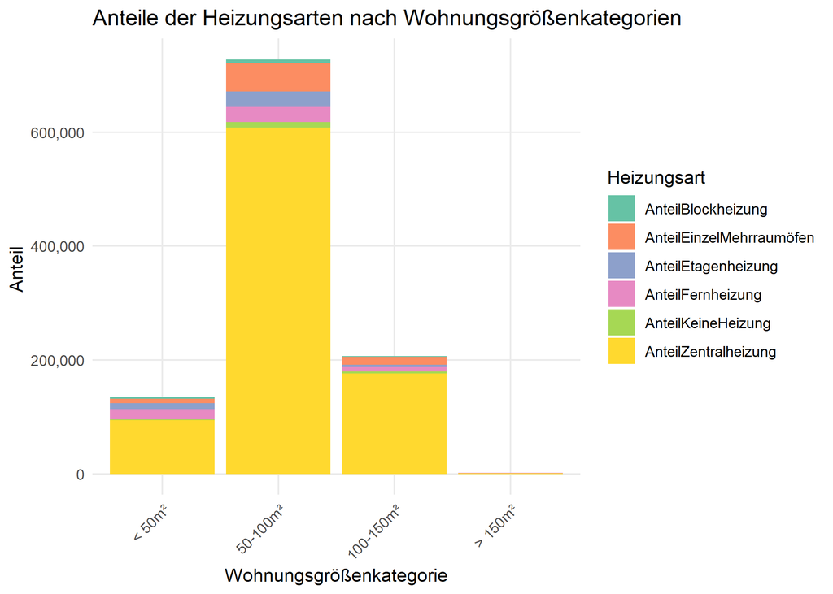

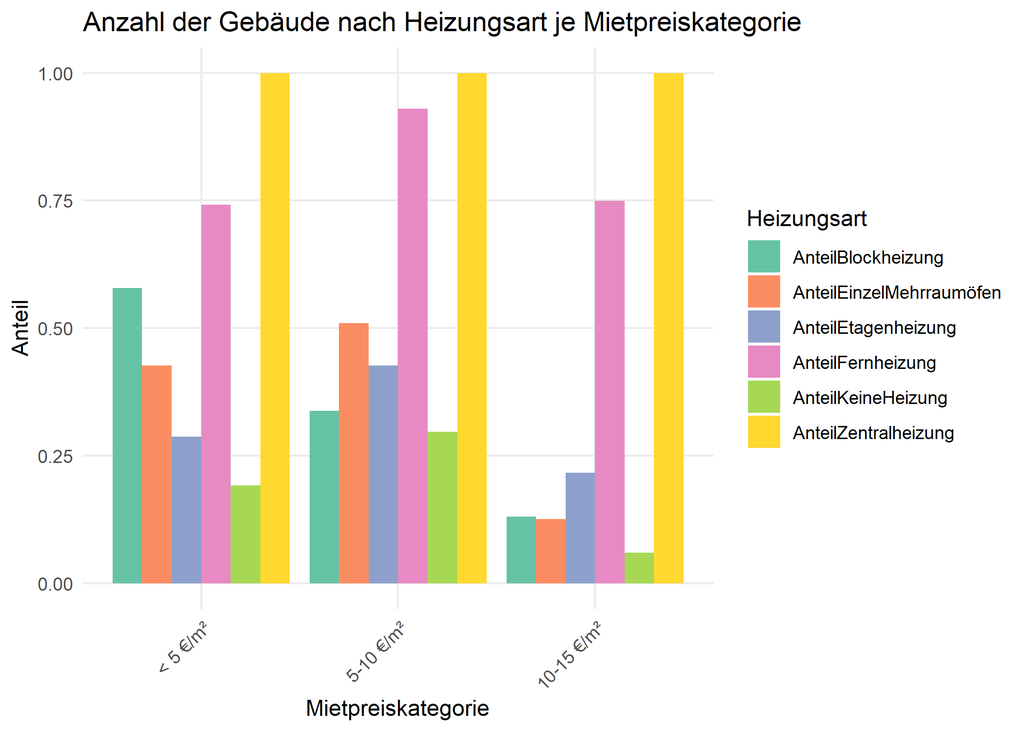

Der oberen Grafik lässt sich entnehmen, dass der Großteil aller Wohnungen mit Zentralheizung beheizt wird. Diese führt in allen Kategorien deutlich. Andere Heizungsarten sind wesentlich weniger verbreitet.

Ein vergleichbares Bild zeigt sich, wenn wir die Anteile der Heizungsarten in Bezug auf die Mietpreise betrachten. Die beiden dominierenden Heizungsarten sind dabei Zentral- und Fernheizung in jeder Kategorie. Lediglich die Verteilung der anderen Heizungstypen variiert zwischen den einzelnen Kategorien.

Wie Sie in der Aufgabe 15 gesehen haben, haben Ulm und Stuttgart, sowie Dresden und Chemnitz ähnliche Verhältnisse bezüglich der Verteilung der Mietkosten über die Stadt hinweg. Aufgrund dessen beschränken Sie sich bei dieser Aufgabe auf die Städte Stuttgart und Dresden. Hier sollen Sie sich die einzelnen Heizungsarten über die Stadtteile hinweg anschauen, wie sich diese verteilen und ob hier Ähnlichkeiten zur Mietpreissstrukur vorliegt. Weiterhin sind vor allem die Heizungsarten Fernwärme, Zentralheizung und Etagenheizung in viele deutschen Wohnungen größtenteils verbaut, weshalb Sie gerade deswegen diese drei Heiztypen genauer beleuchten und untersuchen sollen.

19. Deshalb sollten Sie sich in einem ersten Schritt [diese Geogitter-Daten für die verschiedenen Heinzungsarten vom statistischen Bundesamt herunterladen](https://www.zensus2022.de/static/Zensus_Veroeffentlichung/Zensus2022_Heizungsart.zip). Speichern Sie die zip-Datei im Ordner `Daten` ab. Nutzen Sie erneut den Datensatz shape_file aus der Aufgabe 4 und joinen Sie die Informationen zu den Heizungsarten über die Variablen `x_mp_1km` und `y_mp_1km`.

In ihrem Datensatz können Sie sehen, dass es Einträge mit “-” gibt. Diese sollen sie für alle Heizungstypen durch 0 ersetzen. Achten Sie auch darauf, dass über alle Heizungstypen hinweg die Werte als numeric vorliegen.

Erstellen Sie nun für die Heizungsarten “Fernheizung”, “Etagenheizung” und “Zentralheizung” eine neue Spalte mit dem Anteil des jeweiligen Heizungstyps an allen Heizungen (`Insgesamt_Heizungsart`) je Gemeinde. Schließlich sollen Sie nun für die drei genannten Heizungsarten eine Karte erzeugen, welche den Anteil je Gitterebene im Stadtbezirk darstellt.

Beschreiben und interpretieren Sie ihre Grafiken. Berücksichtigen Sie dabei insbesondere folgende Fragen:

- Wo liegen Besonderheiten oder Muster in beiden Städten?
- Gibt es in Stuttgart und Dresden Stadtteile, bei denen bestimmte Heizungstypen in Einklang mit den Mietpreisen stehen, genauer gesagt, welche Heizungsarten korrelieren mit höheren oder niedrigeren Mietpreisen? Vergleichen Sie dazu die Ergebnisse aus Aufgabe 15.
- Was könnten Gründe sein, dass in bestimmten Stadtteilen vorwiegend eine bestimmte Form der Heizung eingebaut ist?
- Gibt es Unterschiede zwischen Ost- und Westdeutschland?
- Haben die Städte Stuttgart oder Dresden in den letzen Jahren Modernisierungen angestoßen oder Neuerungen umgesetzt und finanziell unterstützt, sodass es dort zu größeren Anpassungen bei der Heizungstechnik kam?

*Hinweis 1:* Sie sollen insgesamt für jede Stadt (Stuttgart und Dresden) drei verschiedene Karten erzeugen.

*Hinweis 2:* Achten Sie auf eine sinnvolle Einteilung und Darstellung in den Karten. Nutzen Sie die Karten aus vorherigen Aufgaben als Hilfestellung.

Abschließend sollen Sie die Zusatzaufgabe noch einmal rekapitulieren und einige Fragen dazu beantworten.

20. Sie sollen sich noch einmal bewusst werden, was Sie in den vorherigen Aufgaben analysiert haben und in welcher Form ihre Ergebnisse anwendbar und verallgemeinbar sind. Beantworten Sie dazu Frage 1 und 2.

Frage 1: Betrachten Sie hierzu noch einmal exemplarisch die Städte Stuttgart und Dresden.

- Sind die Zusammenhänge zwischen Mietpreisen in den Städten und sozioökonomischer Faktoren vor allem auf Unterschiede zwischen den Städten oder auf Unterschiede innerhalb der Stadt zurückzuführen. Bei welchen Faktoren ist dies der Fall, wo nicht?
- Wie kann der Staat im Hinblick auf die unterschiedlichen Heizungsarten in den Städten eingreifen, um Wohnraum preiswerter zu gestalten?

Frage 2: Schauen Sie sich noch einmal die Verteilung der Heizungsarten (Fern-, Etagen- und Zentralheizungen) für Stuttgart und Dresden in Aufgabe 19 an. Betrachten Sie im Vergleich dazu ihre Grafik aus Aufgabe 8, sowie ihre Tabelle in Aufgabe 13?

- Was fällt Ihnen hier auf?
- Gibt es bestimmte Heizungstypen, die nur in alten oder neuen Wohnungen vorkommen?
- Welche Schlüsse würden Sie ziehen, die mit Handlungen der Politik einhergehen?